# PCA tutorial

Giang Vu - JVN

This is an a basic tutoral meant to get you started using PCA on the dataset. I will walk you through a trivival application of PCA on 3 currencies pair USD, AUD, CAD vs EUR.

Start by installing “quantmod”" package to download data

```r
install.packages("quantmod")
library("quantmod")
```

Now we can download the data with function “getFX”"

```r
getFX("EUR/USD", from = "2013-01-01", to = "2017-03-01")
getFX("EUR/AUD", from = "2013-01-01", to = "2017-03-01")
getFX("EUR/CAD", from = "2013-01-01", to = "2017-03-01")
```

Merge the data into one data frame

```r
currencies = as.data.frame(merge(EURAUD, EURCAD, EURUSD))
head(currencies)
```

|  | EUR.AUD | EUR.CAD | EUR.USD |
| --- | --- | --- | --- |
| 2013-01-01 | 1.27099 | 1.31302 | 1.31973 |
| 2013-01-02 | 1.26432 | 1.30724 | 1.32351 |
| 2013-01-03 | 1.25083 | 1.29463 | 1.31322 |
| 2013-01-04 | 1.24801 | 1.28849 | 1.30354 |
| 2013-01-05 | 1.24699 | 1.29025 | 1.30690 |
| 2013-01-06 | 1.24706 | 1.29028 | 1.30695 |

It might be a good idea to take a look at some of the data

```r
plot(currencies$EUR.AUD, type="l", col="darkgreen", ylab="Currency", xlab="Time", ylim=c(0.9, 1.6))
lines(currencies$EUR.USD, col="red")
```

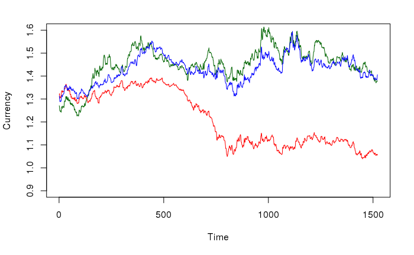

```r
lines(currencies$EUR.CAD, col="blue")
```

Clearly, things are pretty correlated, at leat during some period. Now we want to use PCA on our dataset.

```r
pca = prcomp(x=currencies, center=T)
pca
```

```
Standard deviations:
[1] 0.11991598 0.08977016 0.02715591

Rotation:
               PC1       PC2         PC3
EUR.AUD  0.2812783 0.7456268  0.60408867
EUR.CAD  0.1249942 0.5956741 -0.79344110
EUR.USD -0.9514510 0.2986853  0.07435119
```

To look at the detail how our PCs look like

```r
ls(pca)
```

```
[1] "center"   "rotation" "scale"    "sdev"     "x"
```

```r
pca$rotation
```

```
               PC1       PC2         PC3
EUR.AUD  0.2812783 0.7456268  0.60408867
EUR.CAD  0.1249942 0.5956741 -0.79344110
EUR.USD -0.9514510 0.2986853  0.07435119
```

Let’s compute how much of the variance each factor explains

```r
pca$sdev^2 / sum(pca$sdev^2)
```

[output not shown]

So it turns out that the USD and AUD factor versus CAD is not important, it explains only 3% variance of the dataset. The others two are important cause they explain 62% and 35% variance respectively.

Lets come back to the interpretation of our PCs. The first PC has a very high negative weight on the factor USD, while slightly positive weights on two others. It means that a large amount of dataset’s variance is explained by the movement of USD vs the others currencies.

You may wonder how these things vary over time. You can answer that question by rolling PCA. In other words, we do PCA on windows of times (that shift over) and then look at the factors over time.

To illustrate this, let’s look at the following code that plots the PC. First we create a function which returns the first PC for each dataset x

```r
get_PCs <- function(x){
  my_pca = prcomp(x)
  return(my_pca$rotation[,1]) #  1 is for the first PC
}
```

```r
library("zoo")
window_size = 90
result = rollapply(data=currencies, width=window_size, FUN=get_PCs, by.column=FALSE)
head(result)
```

```
       EUR.AUD   EUR.CAD   EUR.USD
[1,] 0.6579606 0.4856836 0.5754991
[2,] 0.6580215 0.4825600 0.5780514
[3,] 0.6592362 0.4787994 0.5797920
[4,] 0.6610277 0.4712681 0.5839082
[5,] 0.6635084 0.4620450 0.5884480
[6,] 0.6649654 0.4526694 0.5940635
```

Now plot our first PC over time

```r
par(mfrow=c(3,1))
plot(result[,1], type="l", ylab="AUD")
plot(result[,2], type="l", ylab="CAD")
```

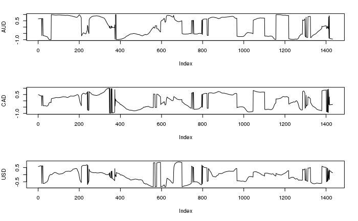

```r
plot(result[,3], type="l", ylab="USD")
```

This tells us nothing. Everything is shifting arround. Here we run into problems:

1. PCs is roration invariant. In our example, the PC2 has all positive weight. It will mean the same thing if all the weights are negative. If we do PCA multiple times, we will get both signs, we need to recognize that this means the same thing.
2. PCs might switch position. PC1 and PC2 may sometimes switch the positions (because our process is not stationanry). So we need a way to identify what a PC actually is.

We need a function that correct these sort of things. Here is one of the solution

```r
amend <- function(result) {
  result.m <- as.matrix(result)
  n <- dim(result.m)[1]
  delta <- apply(abs(result.m[-1,] - result.m[-n,]), 1, sum)
  delta.1 <- apply(abs(result.m[-1,] + result.m[-n,]), 1, sum)
  signs <- c(1, cumprod(rep(-1, n-1) ^ (delta.1 <= delta)))
  zoo(result * signs)
}
```

Apply the above function to amend our result

```r
result = amend(result)
par(mfrow=c(3,1))
plot(result[,1], type="l", ylab="AUD")
plot(result[,2], type="l", ylab="CAD")
```

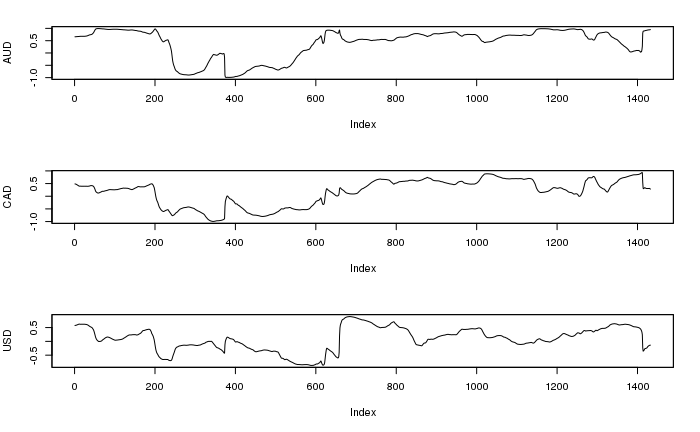

```r
plot(result[,3], type="l", ylab="USD")
```

It looks now much more better. We have a more stable weights of the first PC.